# Predicting the method of exercise through data from wearable devices

```
Author: Srinivasan Sastry    Date: April 02, 2016
```

# Overview

Wearable devices such as Jawbone Up, Nike FuelBand, and Fitbit helps collect data about personal activity or exercises.This data is used extensively used for analysis or prediction. However the quality of the exercises is often not accounted. In order to measure how well exercises are done, six young health participants were asked to perform one set of 10 repetitions of the Unilateral Dumbbell Biceps Curl in five different fashions: exactly according to the specification (Class A), throwing the elbows to the front (Class B), lifting the dumbbell only halfway (Class C), lowering the dumbbell only halfway (Class D) and throwing the hips to the front (Class E).By analyzing this data the researchers of the following paper [“Qualitative Activity Recognition of Weight Lifting Exercises”](http://groupware.les.inf.puc-rio.br/public/papers/2013.Velloso.QAR-WLE.pdf), expect to detect mistakes of execution of exercises in the future.More information is available from the website here: http://groupware.les.inf.puc-rio.br/har (see the section on the Weight Lifting Exercise Dataset). The method of exercises performed is provided as a “classe” variable in the training set. The goal of this project is to predict the “classe” outcome for 20 cases in the testing set.

# Data preparation and exploratory Analysis

The data from training and testing set are loaded. The “Training” set is analyzed. The training set has 19622 observations and 160 variables in the data. There a about 100 variables that have less than 400 observations. So the training set is pruned to take in only the variables that have more than 50% observations filled. The observations are plotted to see if there is any pattern in the data set

```r
library(caret)
library(dplyr)

training <- read.csv('pml-training.csv')
testing <- read.csv('pml-testing.csv')

set.seed(1234)
# Convert all blank cells to NA
# remove the columns more than 50% NAs

training[training == ""] <- NA
t <- apply(training, 2, function(x) (length(which(is.na(x))) < 0.5*length(x)))
training_subset <-  training[,t]
```

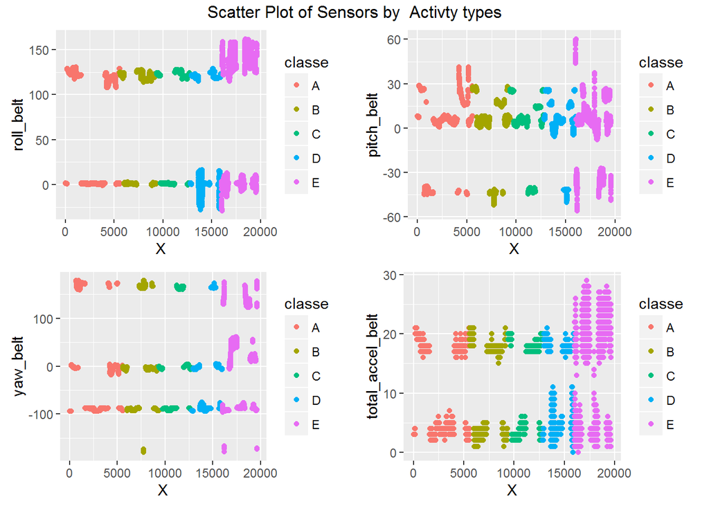

The scatter plot above shows that the data is neatly arranged based on the classe variable. When we model based on this data (not shown),an accuracy of 1 was obtained from Random Forest. when closely observing this data and cross validating with validation data it was observed that the model predominantly was influenced by the arrangement of the data and the predicted values was determined by the variable ‘X’ in the training set. so in the second pass, some more variables that were either falsely contributing or not contributing to the prediction model was removed. The same is done for the testing data set.

```r
training_subset  <- training_subset[,-c(1:7)]
training_subset$classe <- as.factor(training_subset$classe)
testing[testing == ""] <- NA
t1 <- apply(testing, 2, function(x) (length(which(is.na(x))) < 0.5*length(x)))
testing_subset <- testing[,t1]
testing_subset <- subset(testing_subset, select = -problem_id)
```

# Training and cross validation

75% of the train set thus obtained from previous set is taken as a Training set and 25% is held out for validation. Some of the models do have a natural cross validation in them like random forest or bagging, so this step may not be necessary. A correlation plot was plotted (not shown) between the numeric or integer variables to understand the relationships between these variables.

```r
library(AppliedPredictiveModeling)
inTrain = createDataPartition(training_subset$classe, p = 3/4)[[1]]
train <- training_subset[inTrain,]
validation <- training_subset[-inTrain,]
```

we set it for parallel mode run for future caret machine learining algorithms.

```r
# try rpart since data seems to be nicely classified
library(parallel)
library(doParallel)
cluster <- makeCluster(detectCores() - 1) # convention to leave 1 core for OS
registerDoParallel(cluster)
```

## Tree Model

A simple tree Model was created using Rpart with classe variable against the other variables as predictors, since the data seems to be nicely classified and we can observe the accuracy of the model.

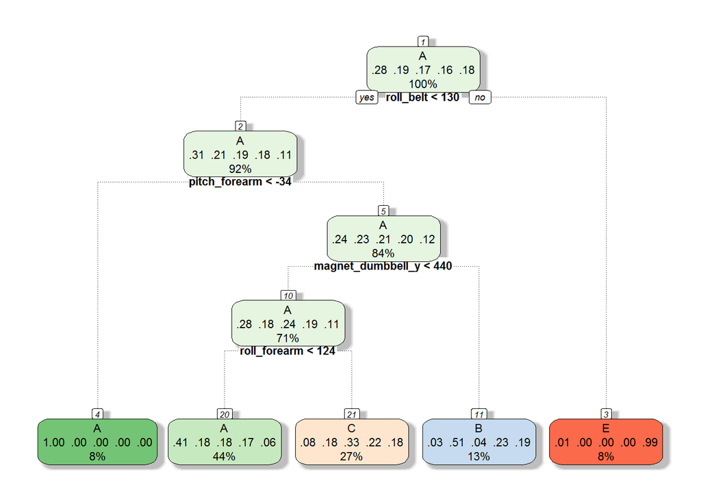

```r
# rpart Model
set.seed(5678)
modfit_rpart <- train(classe ~ ., method = "rpart",data = train)
library(rattle)
fancyRpartPlot(modfit_rpart$finalModel,cex = 0.7,sub="")
```

```r
valPred <- predict(modfit_rpart,newdata = validation)
modfit_rpart
```

```
## CART
##
## 14718 samples
##    52 predictor
##     5 classes: 'A', 'B', 'C', 'D', 'E'
##
## No pre-processing
## Resampling: Bootstrapped (25 reps)
## Summary of sample sizes: 14718, 14718, 14718, 14718, 14718, 14718, ...
## Resampling results across tuning parameters:
##
##   cp          Accuracy   Kappa       Accuracy SD  Kappa SD
##   0.03446312  0.5158735  0.37276909  0.02727075   0.04338700
##   0.05987531  0.4263188  0.22698627  0.06432154   0.10751002
##   0.11535175  0.3254315  0.06398037  0.04236046   0.06278048
##
## Accuracy was used to select the optimal model using  the largest value.
## The final value used for the model was cp = 0.03446312.
```

```r
confusionMatrix(valPred,validation$classe)
```

```
## Confusion Matrix and Statistics
##
##           Reference
## Prediction    A    B    C    D    E
##          A 1275  390  416  356  134
##          B   28  340   31  141  131
##          C   88  219  408  307  230
##          D    0    0    0    0    0
##          E    4    0    0    0  406
##
## Overall Statistics
##
##                Accuracy : 0.4953
##                  95% CI : (0.4812, 0.5094)
##     No Information Rate : 0.2845
##     P-Value [Acc > NIR] : < 2.2e-16
##
##                   Kappa : 0.3399
##  Mcnemar's Test P-Value : NA
##
## Statistics by Class:
##
##                      Class: A Class: B Class: C Class: D Class: E
## Sensitivity            0.9140  0.35827   0.4772   0.0000  0.45061
## Specificity            0.6307  0.91631   0.7916   1.0000  0.99900
## Pos Pred Value         0.4959  0.50671   0.3259      NaN  0.99024
## Neg Pred Value         0.9486  0.85613   0.8776   0.8361  0.88985
## Prevalence             0.2845  0.19352   0.1743   0.1639  0.18373
## Detection Rate         0.2600  0.06933   0.0832   0.0000  0.08279
## Detection Prevalence   0.5243  0.13683   0.2553   0.0000  0.08361
## Balanced Accuracy      0.7723  0.63729   0.6344   0.5000  0.72481
```

we observe that accuracy obtained with the testing data set is low. Also it is observed that the sensitivity or specificity values are not high enough to ascertain that this tree model will be good for our prediction.It might be possible to tune this model using parameters. However other models are tried before need for tuning this model.

# Bagging Model

A Bagging Model was created using “Bagging” model function from iPred with classe variable against the other variables as predictors. This was chosen over ‘bag’ from caret because of performance.

```r
#Bagging Model
set.seed(13141516)
library(ipred)
modfit_bag <- bagging(classe ~. , data = train,coob=TRUE)
valPred_bag <- predict(modfit_bag,newdata = validation)
modfit_bag
```

```
##
## Bagging classification trees with 25 bootstrap replications
##
## Call: bagging.data.frame(formula = classe ~ ., data = train, coob = TRUE)
##
## Out-of-bag estimate of misclassification error:  0.0128
```

```r
confusionMatrix(valPred_bag,validation$classe)
```

```
## Confusion Matrix and Statistics
##
##           Reference
## Prediction    A    B    C    D    E
##          A 1393    6    0    0    0
##          B    2  937    9    3    1
##          C    0    6  842    7    2
##          D    0    0    4  793    1
##          E    0    0    0    1  897
##
## Overall Statistics
##
##                Accuracy : 0.9914
##                  95% CI : (0.9884, 0.9938)
##     No Information Rate : 0.2845
##     P-Value [Acc > NIR] : < 2.2e-16
##
##                   Kappa : 0.9892
##  Mcnemar's Test P-Value : NA
##
## Statistics by Class:
##
##                      Class: A Class: B Class: C Class: D Class: E
## Sensitivity            0.9986   0.9874   0.9848   0.9863   0.9956
## Specificity            0.9983   0.9962   0.9963   0.9988   0.9998
## Pos Pred Value         0.9957   0.9842   0.9825   0.9937   0.9989
## Neg Pred Value         0.9994   0.9970   0.9968   0.9973   0.9990
## Prevalence             0.2845   0.1935   0.1743   0.1639   0.1837
## Detection Rate         0.2841   0.1911   0.1717   0.1617   0.1829
## Detection Prevalence   0.2853   0.1941   0.1748   0.1627   0.1831
## Balanced Accuracy      0.9984   0.9918   0.9905   0.9925   0.9977
```

The Out-of-bag estimate of misclassification error: 0.0128 is very low and accuracy seems very high. As noted from the model this is over 25 resampling that is done. The results seems good. the sensitivity and specificity values is very high suggesting that our TYPE I and TYPE II errors will be low. A few more models will be evaluated before chossing a final one to run on the test data for prediction.

## Boosting Model

The caret “gbm” boosting method was used in order to overcome the 2 class limit posed by the boosting model from iPred. However the procedure was very slow.

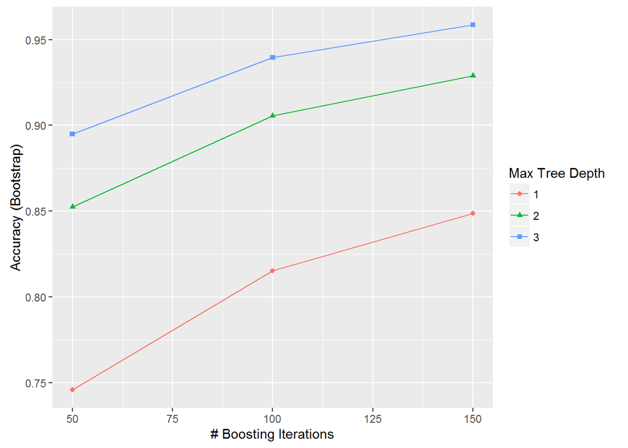

```r
#Boosting Model
set.seed(9101112)
library(dplyr)
predictors  <- subset(train , select = -classe)
classe <- train$classe
modfit_boost <- train(predictors ,classe, method = "gbm")
valPred_boost <- predict(modfit_boost,newdata = validation[,colnames(predictors)])
modfit_boost
confusionMatrix(valPred_boost,validation$classe)
ggplot(modfit_boost)
```

[output not shown]

```r
#Random Forest
set.seed(17181920)
library(randomForest)
modfit_rf <- randomForest(classe ~.,data = train,importance = TRUE)
valPred_rf <- predict(modfit_rf,newdata = validation)
modfit_rf
```

```
##
## Call:
##  randomForest(formula = classe ~ ., data = train, importance = TRUE)
##                Type of random forest: classification
##                      Number of trees: 500
## No. of variables tried at each split: 7
##
##         OOB estimate of  error rate: 0.49%
## Confusion matrix:
##      A    B    C    D    E  class.error
## A 4182    3    0    0    0 0.0007168459
## B   13 2829    6    0    0 0.0066713483
## C    0   16 2548    3    0 0.0074016362
## D    0    0   19 2391    2 0.0087064677
## E    0    0    3    7 2696 0.0036954915
```

```r
confusionMatrix(valPred_rf,validation$classe)
```

```
## Confusion Matrix and Statistics
##
##           Reference
## Prediction    A    B    C    D    E
##          A 1395    3    0    0    0
##          B    0  943    9    0    0
##          C    0    3  844    6    0
##          D    0    0    2  798    0
##          E    0    0    0    0  901
##
## Overall Statistics
##
##                Accuracy : 0.9953
##                  95% CI : (0.993, 0.997)
##     No Information Rate : 0.2845
##     P-Value [Acc > NIR] : < 2.2e-16
##
##                   Kappa : 0.9941
##  Mcnemar's Test P-Value : NA
##
## Statistics by Class:
##
##                      Class: A Class: B Class: C Class: D Class: E
## Sensitivity            1.0000   0.9937   0.9871   0.9925   1.0000
## Specificity            0.9991   0.9977   0.9978   0.9995   1.0000
## Pos Pred Value         0.9979   0.9905   0.9894   0.9975   1.0000
## Neg Pred Value         1.0000   0.9985   0.9973   0.9985   1.0000
## Prevalence             0.2845   0.1935   0.1743   0.1639   0.1837
## Detection Rate         0.2845   0.1923   0.1721   0.1627   0.1837
## Detection Prevalence   0.2851   0.1941   0.1739   0.1631   0.1837
## Balanced Accuracy      0.9996   0.9957   0.9925   0.9960   1.0000
```

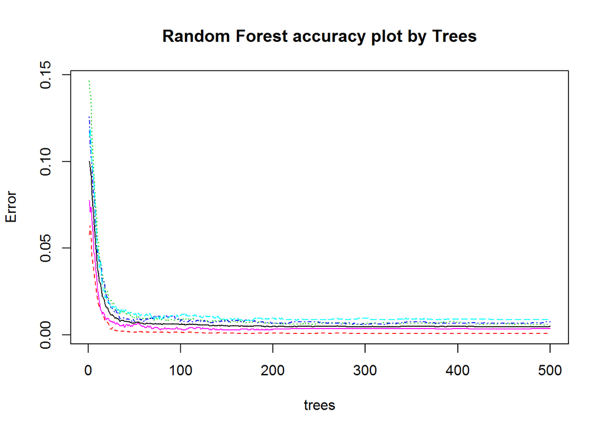

```r
par(op)
plot(modfit_rf,main= "Random Forest accuracy plot by Trees")
```

```r
library(randomForest)
c(Tree = confusionMatrix(valPred,validation$classe)$overall['Accuracy'],
  Bagging = confusionMatrix(valPred_bag,validation$classe)$overall['Accuracy'],
  RandomForest= confusionMatrix(valPred_rf,validation$classe)$overall['Accuracy'],
  Boosting = confusionMatrix(valPred_boost,validation$classe)$overall['Accuracy'])
```

```
##         Tree.Accuracy      Bagging.Accuracy RandomForest.Accuracy
##             0.4953100             0.9914356             0.9953100
##     Boosting.Accuracy
##             0.9655383
```

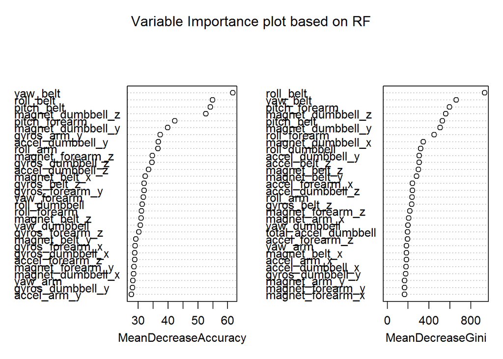

```r
varImpPlot(modfit_rf,main="Variable Importance plot based on RF")
```

In comparing the accuracy the Bagging and Random Forest have the best accuracy followd by boosting. The basic tree model was not accurate enough. The Random Forest scored high in the performance and with other metrics like sensitivity and specificity. This comparison however is not a equal comparison since the parameters not be set equal for instance the depth of trees or the no of trees. However the premise of the challenge is to use a model that will clearly predict the outcome of the testing data set. Hence this cross validation is fair. For predicting the out come of the testing set, RandomForest model is used and results are output to a file.

# Predicting Test data values

The predicted output is written to the “Predicted Output for Test Data.xlsx” in the working directory

```r
valPred_rf_test <- predict(modfit_rf,newdata = testing_subset)
test_df <- data.frame(testing$problem_id,valPred_rf_test)
library(xlsx)
write.xlsx(test_df, "Predicted Output for Test Data.xlsx")
```